# Conflict patterns in Myanmar

Township-level evidence, January 2021 to September 2025

JUNCHEN LI

October 18, 2026

## Study question and data

Where does recorded conflict cluster, and where does clustering change over time?

- **330 townships**, MIMU v9.4 boundaries.
- **57 months**, January 2021 to September 2025.
- **53,992 assigned events**, **89,220 reported fatalities**.
- Battles, explosions/remote violence and violence against civilians.

**Methods:** Global Moran’s I uses 9,999 permutations, local tests 4,999 and space-time Gi* 999, followed by Mann-Kendall trends.

**Overall association:** I = **0.490** for events and **0.558** for fatalities. Both pass the two-test Holm threshold (p = 0.0004).

Main maps show **p < 0.05**. Data-quality alternatives leave adjusted static hotspot sets unchanged.

## Recorded burden through time

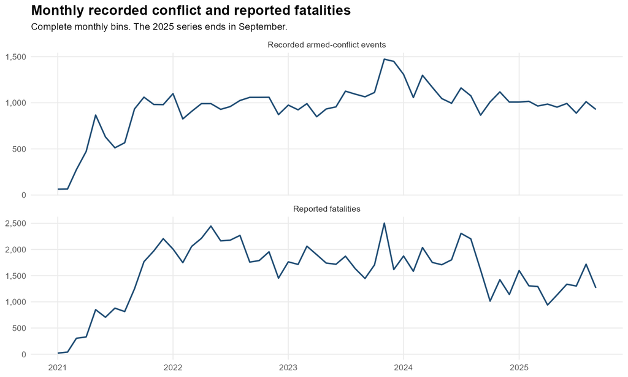

Peak event month: **November 2023**, with **1,473** events. The 2025 series ends in September.

## Event-count clusters and outliers

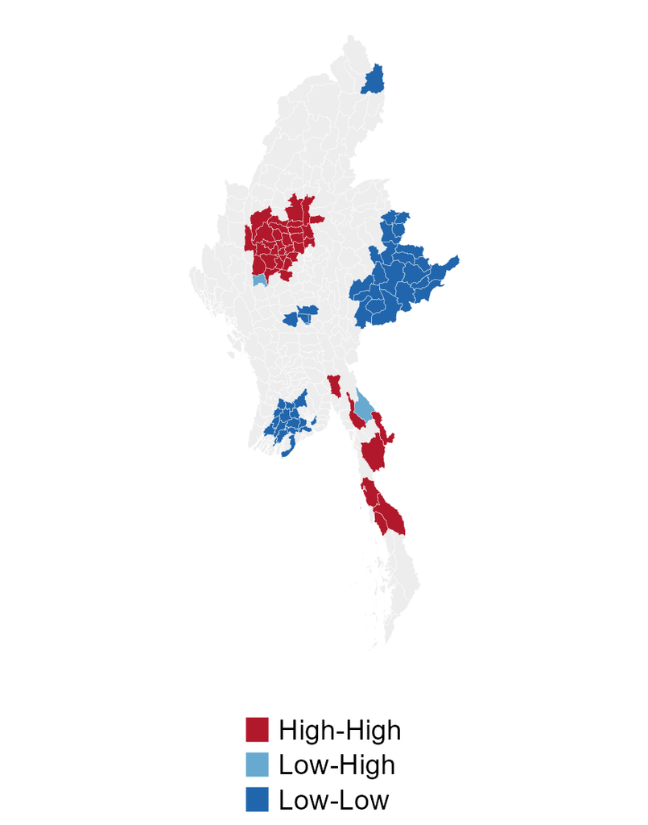

**37 High-High townships**

**2 spatial outliers**

High-High means a high recorded total surrounded by high totals. An outlier differs from its neighbours.

Grey areas are not significant under this test. They are not established safe areas.

Sagaing contains **18 of 37** High-High townships under the Local Moran test shown here.

## Reported-fatality concentrations

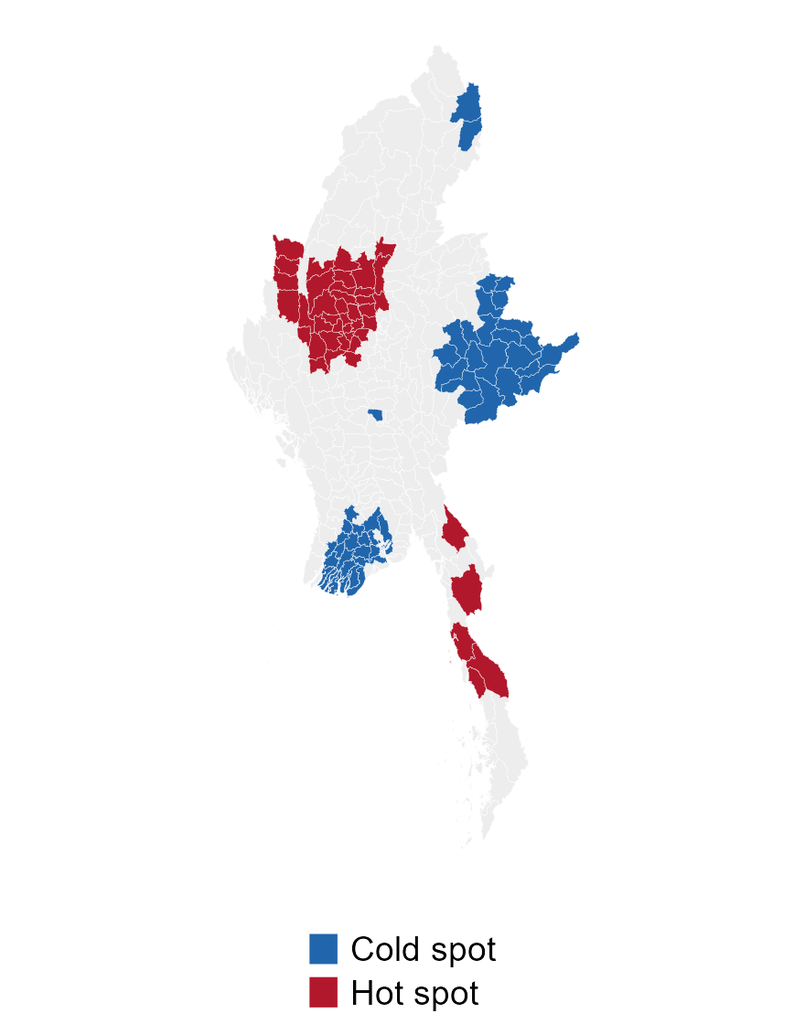

**43 nominal hot spots**

**33 overlap with event-count hot spots**

Fatality totals complement event frequency but can be dominated by severe incidents. Recorded fatalities are estimates, not a verified death toll.

## Emerging event-count patterns

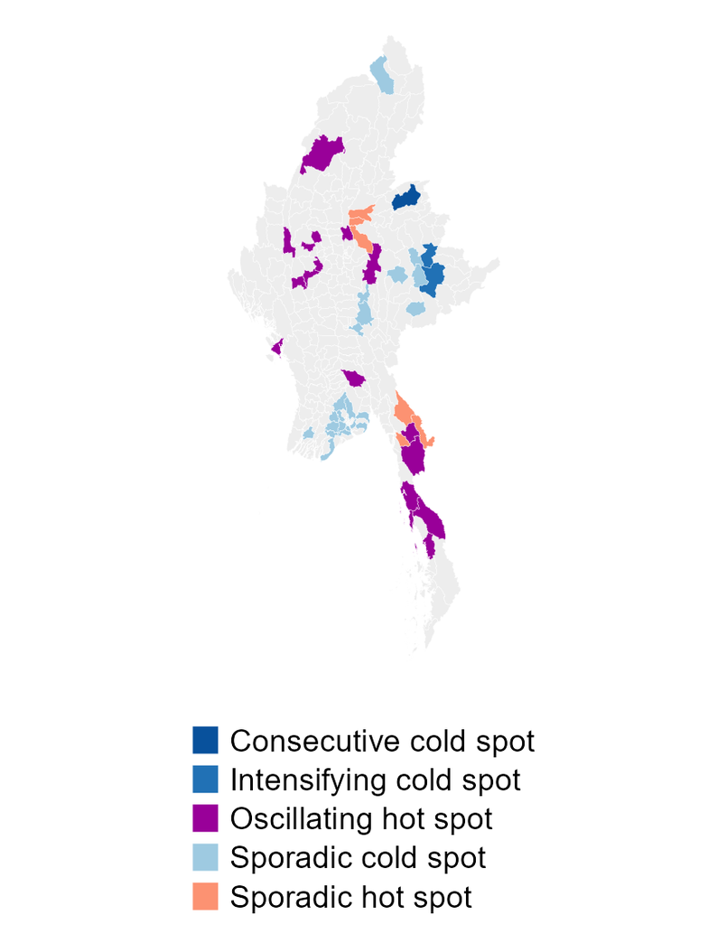

**60 displayed township patterns**

Colour requires a recognised hot/cold pattern and **Mann-Kendall p < 0.05**.

The time neighbourhood includes the current and previous month. Sporadic patterns require a significant final month under the cited Pro 3.4 definitions.

Hot patterns are mainly **6 sporadic** and **17 oscillating** townships.

## Local change against the national trend

| Township | 2024 events | 2025 events | 2024 share % | 2025 share % |
| --- | --- | --- | --- | --- |
| Kawkareik | 122 | 356 | 1.22 | 4.07 |
| Nawnghkio | 202 | 341 | 2.03 | 3.90 |
| Monywa | 215 | 107 | 2.16 | 1.22 |
| Myingyan | 191 | 114 | 1.91 | 1.30 |

January-September comparisons: national events decline **12.3%**, while Kawkareik and Nawnghkio gain both events and national share. Monywa and Myingyan lose event share.

Fatality counts can fall while shares rise: Nawnghkio falls from 91 to 70 fatalities, but its share rises from 0.54% to 0.59% during a larger national decline.

This descriptive benchmark complements the report’s four profiles. It does not remove national trends from the full-period EHSA or estimate population risk.

## Robustness changes the strength of evidence

| Outcome | Displayed trend-patterns | Also pass BH and all block checks |
| --- | --- | --- |
| events | 60 | 14 |
| fatalities | 58 | 23 |

Additional temporal support requires MK BH q < 0.05 and all 3-, 6- and 12-month block p-values < 0.05. Long-block resolution is limited.

BH-adjusted space-time bins leave **22 event** and **0 fatality** patterns displayed.

**Global sensitivity:** Positive Moran association survives **8/8** comparisons of raw/log1p totals and queen/symmetric six-neighbour weights (eight-test Holm p = 0.0016). This supports overall association, not the individual EHSA labels.

**Overall concentration is stable across these checks. Temporal labels remain sensitive.**

## Fatality severity after conditioning on events

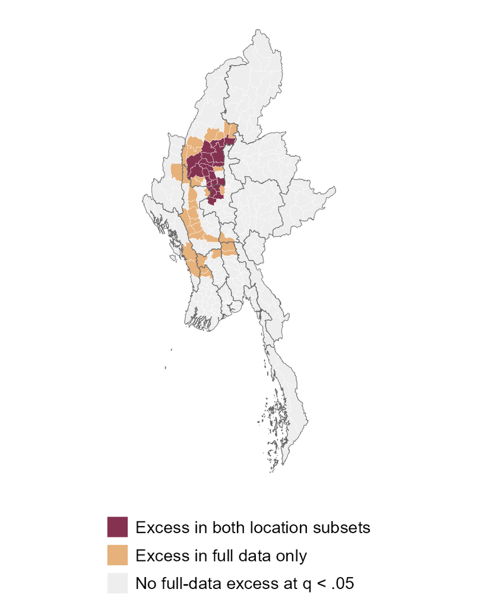

**53 baseline excess-severity neighbourhoods** at BH q < 0.05. Three repeat seeds yield **50 to 58**, so the total is simulation-sensitive.

**21 also pass** in the precise-location subset.

The simulation shuffles fatality marks within month and type while holding event locations fixed.

**Kyunhla, Kawlin and Taze** lie outside ordinary adjusted count hotspots. All **6 of 6 case/sample checks** retain support across repeated seeds and after deleting each neighbourhood’s largest-fatality record.

Each new run uses 1,999 permutations and BH over all 330 neighbourhoods. Overlap, reporting bias and correlated incidents remain limitations.

## Peace-building implications and limits

- Nawnghkio gains event share and passes the additional trend checks. Kawkareik also gains share, but its longer-block result requires caution.
- Monywa illustrates why a grey EHSA area can still have a high accumulated burden.
- Combine recorded conflict with displacement, access and service information before allocating assistance.
- Treat low counts cautiously where reporting coverage may be weak.

The results support retrospective humanitarian discussion. They do not establish safe routes or operational targets.

## Sources and reproducibility

Technical report documents processing, parameters, results and runnable R scripts.

[GitHub repository: JUNCHENLI2026/ISSS626_GAA](https://github.com/JUNCHENLI2026/ISSS626_GAA).

- ACLED event extract supplied for this exercise; [Codebook](https://acleddata.com/methodology/acled-codebook).
- [MIMU GeoNode](https://geonode.themimu.info/), township boundaries v9.4.
- [spdep](https://r-spatial.github.io/spdep/), local spatial tests.
- [Esri Pro 3.4 EHSA definitions](https://pro.arcgis.com/en/pro-app/3.4/tool-reference/space-time-pattern-mining/learnmoreemerging.htm), including the terminal-bin rule.

AI assistance was used to optimise parts of the R code and fix some bugs.